# **Predicting Bank Term Deposit Subscriptions: A Machine Learning Approach to Customer Classification**

#### Team members: Kaviya Appu, Nawal Kazmi, Ngoc Chau Ngo

```python
import numpy as np
import pandas as pd
import matplotlib.pyplot as plt
import seaborn as sns
import warnings
warnings.filterwarnings('ignore')

from sklearn.model_selection      import (train_test_split, StratifiedKFold,
                                           cross_validate, GridSearchCV,
                                           RandomizedSearchCV, learning_curve)
from sklearn.pipeline             import Pipeline
from sklearn.compose              import ColumnTransformer
from sklearn.preprocessing        import StandardScaler, OneHotEncoder, FunctionTransformer
from sklearn.impute               import SimpleImputer
from sklearn.linear_model         import LogisticRegression
from sklearn.tree                 import DecisionTreeClassifier, plot_tree
from sklearn.ensemble             import RandomForestClassifier
from sklearn.metrics              import (accuracy_score, precision_score,
                                           recall_score, f1_score,
                                           roc_auc_score, matthews_corrcoef,
                                           confusion_matrix, classification_report,
                                           roc_curve, precision_recall_curve)
from sklearn.calibration          import calibration_curve
from lightgbm import LGBMClassifier

print("All imports done.")
```

```
All imports done.
```

## Dataset and preprocessing

```python
df = pd.read_csv("/content/sample_data/train.csv")
print(df.shape)
df.head(15)
```

```
(45211, 17)
```

|  | age | job | marital | education | default | balance | housing | loan | contact | day | month | duration | campaign | pdays | previous | poutcome | y |
| --- | --- | --- | --- | --- | --- | --- | --- | --- | --- | --- | --- | --- | --- | --- | --- | --- | --- |
| 0 | 58 | management | married | tertiary | no | 2143 | yes | no | unknown | 5 | may | 261 | 1 | -1 | 0 | unknown | no |
| 1 | 44 | technician | single | secondary | no | 29 | yes | no | unknown | 5 | may | 151 | 1 | -1 | 0 | unknown | no |
| 2 | 33 | entrepreneur | married | secondary | no | 2 | yes | yes | unknown | 5 | may | 76 | 1 | -1 | 0 | unknown | no |
| 3 | 47 | blue-collar | married | unknown | no | 1506 | yes | no | unknown | 5 | may | 92 | 1 | -1 | 0 | unknown | no |
| 4 | 33 | unknown | single | unknown | no | 1 | no | no | unknown | 5 | may | 198 | 1 | -1 | 0 | unknown | no |
| 5 | 35 | management | married | tertiary | no | 231 | yes | no | unknown | 5 | may | 139 | 1 | -1 | 0 | unknown | no |
| 6 | 28 | management | single | tertiary | no | 447 | yes | yes | unknown | 5 | may | 217 | 1 | -1 | 0 | unknown | no |
| 7 | 42 | entrepreneur | divorced | tertiary | yes | 2 | yes | no | unknown | 5 | may | 380 | 1 | -1 | 0 | unknown | no |
| 8 | 58 | retired | married | primary | no | 121 | yes | no | unknown | 5 | may | 50 | 1 | -1 | 0 | unknown | no |
| 9 | 43 | technician | single | secondary | no | 593 | yes | no | unknown | 5 | may | 55 | 1 | -1 | 0 | unknown | no |
| 10 | 41 | admin. | divorced | secondary | no | 270 | yes | no | unknown | 5 | may | 222 | 1 | -1 | 0 | unknown | no |
| 11 | 29 | admin. | single | secondary | no | 390 | yes | no | unknown | 5 | may | 137 | 1 | -1 | 0 | unknown | no |
| 12 | 53 | technician | married | secondary | no | 6 | yes | no | unknown | 5 | may | 517 | 1 | -1 | 0 | unknown | no |
| 13 | 58 | technician | married | unknown | no | 71 | yes | no | unknown | 5 | may | 71 | 1 | -1 | 0 | unknown | no |
| 14 | 57 | services | married | secondary | no | 162 | yes | no | unknown | 5 | may | 174 | 1 | -1 | 0 | unknown | no |

## EDA (on raw data)

```python
# Save a clean copy for EDA — never touch this copy
df_original = df.copy()

print('Shape:', df_original.shape)
print('\nColumn Names:\n', df_original.columns.tolist())
print('\nData Types:\n', df_original.dtypes)
print('\nBasic Statistics:\n', df_original.describe())
```

```
Shape: (45211, 17)

Column Names:
 ['age', 'job', 'marital', 'education', 'default', 'balance', 'housing', 'loan', 'contact', 'day', 'month', 'duration', 'campaign', 'pdays', 'previous', 'poutcome', 'y']

Data Types:
 age           int64
job          object
marital      object
education    object
default      object
balance       int64
housing      object
loan         object
contact      object
day           int64
month        object
duration      int64
campaign      int64
pdays         int64
previous      int64
poutcome     object
y            object
dtype: object

Basic Statistics:
                 age        balance           day      duration      campaign  \
count  45211.000000   45211.000000  45211.000000  45211.000000  45211.000000
mean      40.936210    1362.272058     15.806419    258.163080      2.763841
std       10.618762    3044.765829      8.322476    257.527812      3.098021
min       18.000000   -8019.000000      1.000000      0.000000      1.000000
25%       33.000000      72.000000      8.000000    103.000000      1.000000
50%       39.000000     448.000000     16.000000    180.000000      2.000000
75%       48.000000    1428.000000     21.000000    319.000000      3.000000
max       95.000000  102127.000000     31.000000   4918.000000     63.000000

              pdays      previous
count  45211.000000  45211.000000
mean      40.197828      0.580323
std      100.128746      2.303441
min       -1.000000      0.000000
25%       -1.000000      0.000000
50%       -1.000000      0.000000
75%       -1.000000      0.000000
max      871.000000    275.000000
```

```python
# Class imbalance check
print('Target Variable Count:')
print(df_original['y'].value_counts())
print('\nTarget Variable Percentage:')
print(df_original['y'].value_counts(normalize=True) * 100)
```

```
Target Variable Count:
y
no     39922
yes     5289
Name: count, dtype: int64

Target Variable Percentage:
y
no     88.30152
yes    11.69848
Name: proportion, dtype: float64
```

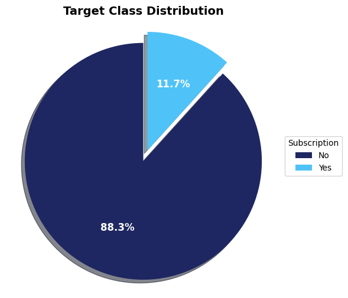

```python
import matplotlib.pyplot as plt

# Get target variable distribution from df_original
target_distribution = df_original['y'].value_counts(normalize=True) * 100
labels = ['No', 'Yes']
sizes = [target_distribution['no'], target_distribution['yes']]
colors = ['#1E2761', '#4FC3F7'] # Matching colors from the deleted cell
explode = (0, 0.1) # Explode the 'Yes' slice for emphasis

fig, ax = plt.subplots(figsize=(6, 6))
ax.pie(sizes, explode=explode, labels=labels,
       autopct='%1.1f%%', colors=colors, shadow=True, startangle=90,
       textprops={'fontsize': 12, 'color': 'white', 'fontweight': 'bold'}) # Changed color to white
ax.axis('equal')  # Equal aspect ratio ensures that pie is drawn as a circle.
ax.set_title('Target Class Distribution', fontsize=14, fontweight='bold')
ax.legend(labels, title="Subscription", loc="center left", bbox_to_anchor=(1, 0, 0.5, 1)) # Added explicit legend
plt.show()
```

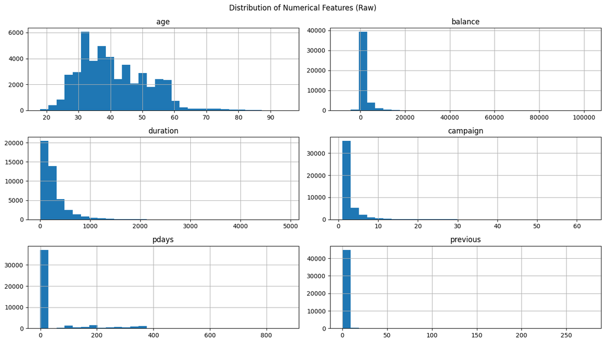

```python
num_cols_raw = ['age', 'balance', 'duration', 'campaign', 'pdays', 'previous']
df_original[num_cols_raw].hist(figsize=(14, 8), bins=30)
plt.suptitle('Distribution of Numerical Features (Raw)')
plt.tight_layout()
plt.show()
```

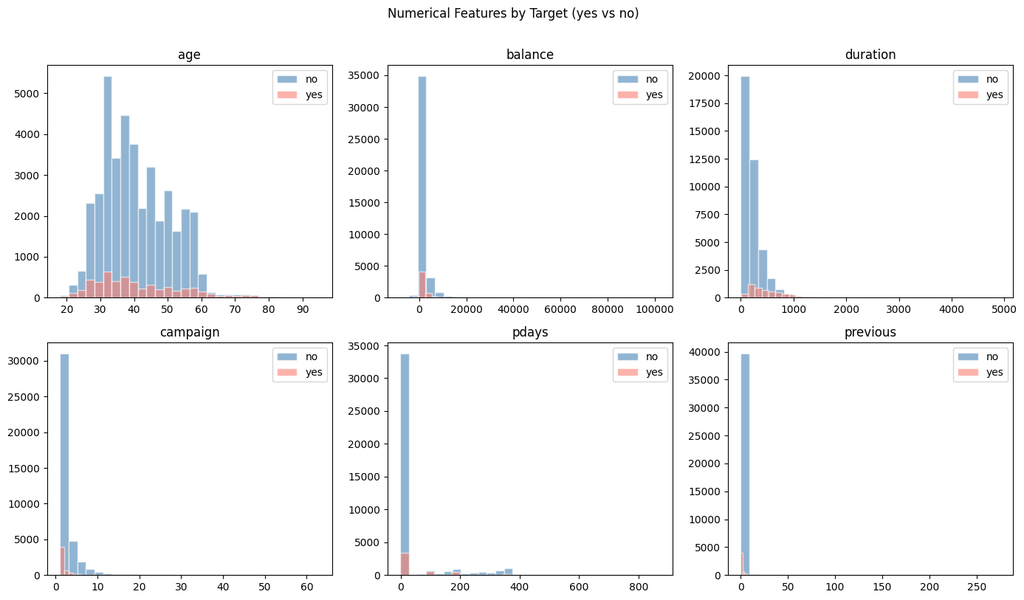

```python
fig, axes = plt.subplots(2, 3, figsize=(14, 8))
axes = axes.flatten()

for i, col in enumerate(num_cols_raw):
    for label, color in [('no', 'steelblue'), ('yes', 'salmon')]:
        subset = df_original[df_original['y'] == label][col]
        axes[i].hist(subset, bins=30, alpha=0.6,
                     color=color, label=label, edgecolor='white')
    axes[i].set_title(col)
    axes[i].legend()

plt.suptitle('Numerical Features by Target (yes vs no)', y=1.01)
plt.tight_layout()
plt.show()
```

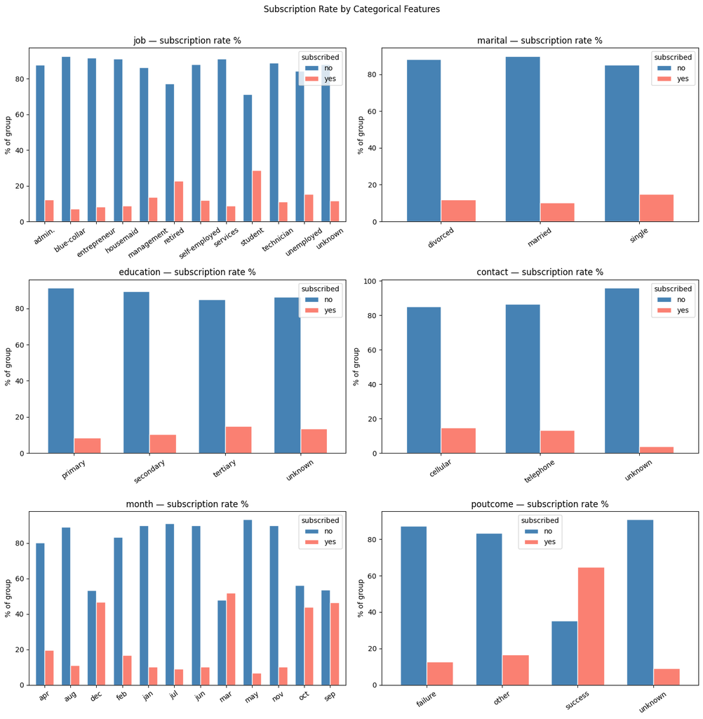

```python
cat_cols = ['job', 'marital', 'education', 'contact', 'month', 'poutcome']

fig, axes = plt.subplots(3, 2, figsize=(14, 14))
axes = axes.flatten()

for i, col in enumerate(cat_cols):
    ct = pd.crosstab(df_original[col], df_original['y'], normalize='index') * 100
    ct.plot(kind='bar', ax=axes[i], color=['steelblue', 'salmon'],
            edgecolor='white', width=0.7)
    axes[i].set_title(f'{col} — subscription rate %')
    axes[i].set_ylabel('% of group')
    axes[i].set_xlabel('')
    axes[i].tick_params(axis='x', rotation=35)
    axes[i].legend(title='subscribed')

plt.suptitle('Subscription Rate by Categorical Features', y=1.01)
plt.tight_layout()
plt.show()
```

```python
print(f"% zeros: {(df_original['previous'] == 0).mean()*100:.1f}%")
```

```
% zeros: 81.7%
```

[figure not shown]

```python
fig, ax = plt.subplots(figsize=(5, 4))

counts = df_raw['y'].value_counts().sort_index()
labels = ['No (88.3%)', 'Yes (11.7%)']
colors = ['#4C72B0', '#DD8452']

bars = ax.bar(labels, counts.values, color=colors,
              edgecolor='white', width=0.5)

ax.bar_label(bars, fmt='%,.0f', padding=4, fontsize=10)
ax.set_ylabel('Number of Observations')
ax.set_title('Target Class Distribution', fontweight='bold')
ax.set_ylim(0, max(counts.values) * 1.15)
ax.spines['top'].set_visible(False)
ax.spines['right'].set_visible(False)

plt.tight_layout()
plt.savefig("class_distribution.pdf", bbox_inches="tight")
plt.show()
```

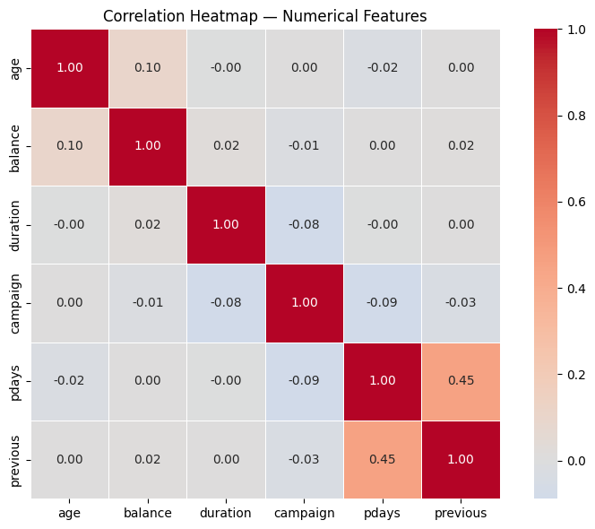

```python
# Correlation on numerical columns only
corr_cols = ['age', 'balance', 'duration', 'campaign', 'pdays', 'previous']
corr = df_original[corr_cols].corr()

plt.figure(figsize=(8, 6))
sns.heatmap(corr, annot=True, fmt='.2f', cmap='coolwarm',
            center=0, square=True, linewidths=0.5)
plt.title('Correlation Heatmap — Numerical Features')
plt.tight_layout()
plt.show()
```

```python
print(df.isnull().sum())
df = df.dropna()
print('\nShape after dropna:', df.shape)
```

```
age          0
job          0
marital      0
education    0
default      0
balance      0
housing      0
loan         0
contact      0
day          0
month        0
duration     0
campaign     0
pdays        0
previous     0
poutcome     0
y            0
dtype: int64

Shape after dropna: (45211, 17)
```

The dataset contains 45,211 records with 16 features and a binary target (y). Key observations:

Class imbalance: 88.3% "no" vs 11.7% "yes" — accuracy alone will be misleading. F1 and ROC-AUC are used as primary metrics.

duration shows the strongest visual separation between yes/no classes, but is a post-call feature — not available at prediction time. Its impact is quantified in the ablation study.

poutcome_success customers show substantially higher subscription rates, making prior campaign outcome the most actionable targeting signal.

month matters — March, September, and October show higher subscription rates than May, which has the highest call volume but low conversion.

Numerical features are highly skewed (balance, campaign, pdays) — log transforms are applied inside the Pipeline.

## Load raw data + Target encode only

```python
# ═══════════════════════════════════════════════════════════════
#  LOAD RAW DATA
#  Only the target is encoded here — it is not a feature,
#  so encoding it before the split causes zero leakage.
# ═══════════════════════════════════════════════════════════════

df_raw = pd.read_csv("/content/sample_data/train.csv")
df_raw = df_raw.dropna()

# Encode target (not a feature — safe to do before split)
df_raw['y'] = (df_raw['y'] == 'yes').astype(int)

# ── FEATURE ENGINEERING (row-wise, no leakage) ──────
df_raw['was_contacted'] = (df_raw['pdays'] != -1).astype(int)
df_raw['pdays']         = df_raw['pdays'].replace(-1, 0)

# ── FEATURE SELECTION ───────────────────────────────
# previous dropped: 82%+ values are 0 (near-zero variance)
df_raw                  = df_raw.drop(columns=['previous'])

print("Shape:", df_raw.shape)
print("Columns:", df_raw.columns.tolist())
print("\nTarget distribution:")
print(df_raw['y'].value_counts())
```

```
Shape: (45211, 17)
Columns: ['age', 'job', 'marital', 'education', 'default', 'balance', 'housing', 'loan', 'contact', 'day', 'month', 'duration', 'campaign', 'pdays', 'poutcome', 'y', 'was_contacted']

Target distribution:
y
0    39922
1     5289
Name: count, dtype: int64
```

### Define feature groups

```python
# ═══════════════════════════════════════════════════════════════
#  FEATURE GROUPS
#  Each group gets a different preprocessing treatment
#  inside the Pipeline
# ═══════════════════════════════════════════════════════════════

num_features  = ['age', 'balance', 'duration', 'campaign', 'pdays']
bin_features  = ['default', 'housing', 'loan']       # yes/no strings
cat_features  = ['job', 'marital', 'education',
                 'contact', 'month', 'poutcome']      # multi-class strings
pass_features = ['was_contacted']                     # already binary int

X = df_raw.drop(columns=['y'])
y = df_raw['y']

print(f"Total features : {X.shape[1]}")
print(f"Numerical      : {num_features}")
print(f"Binary         : {bin_features}")
print(f"Categorical    : {cat_features}")
print(f"Pass-through   : {pass_features}")
```

```
Total features : 16
Numerical      : ['age', 'balance', 'duration', 'campaign', 'pdays']
Binary         : ['default', 'housing', 'loan']
Categorical    : ['job', 'marital', 'education', 'contact', 'month', 'poutcome']
Pass-through   : ['was_contacted']
```

## Train/Test split FIRST

```python
# ═══════════════════════════════════════════════════════════════
#  SPLIT BEFORE ANYTHING IS FIT
#  X_test is locked away — never used until final evaluation
# ═══════════════════════════════════════════════════════════════

X_train, X_test, y_train, y_test = train_test_split(
    X, y,
    test_size=0.2,
    random_state=42,
    stratify=y
)

print(f"Train : {X_train.shape}  |  Test : {X_test.shape}")
print(f"Train class ratio — no: {(y_train==0).sum()}  yes: {(y_train==1).sum()}")
print(f"Test  class ratio — no: {(y_test==0).sum()}   yes: {(y_test==1).sum()}")
print("\n✅ Test set locked. No preprocessing fitted yet.")
```

```
Train : (36168, 16)  |  Test : (9043, 16)
Train class ratio — no: 31937  yes: 4231
Test  class ratio — no: 7985   yes: 1058

✅ Test set locked. No preprocessing fitted yet.
```

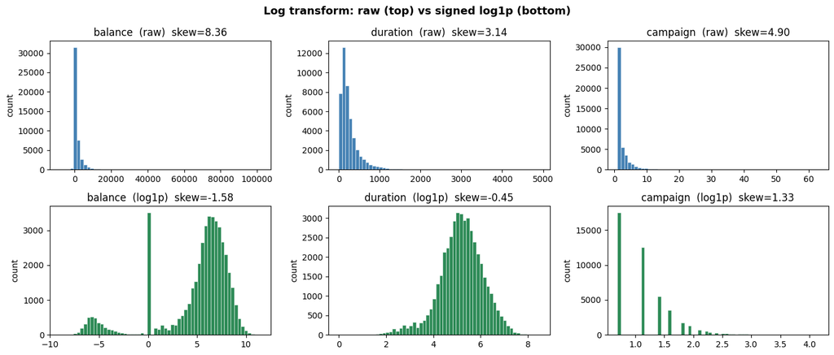

```python
# ── WHY LOG TRANSFORM: before / after plots ────────────────────
skewed_cols = ['balance', 'duration', 'campaign']

fig, axes = plt.subplots(2, 3, figsize=(14, 6))
fig.suptitle('Log transform: raw (top) vs signed log1p (bottom)',
             fontsize=13, fontweight='bold')

for i, col in enumerate(skewed_cols):
    raw    = df_raw[col]
    logged = np.log1p(np.abs(raw)) * np.sign(raw)

    # Top row: raw
    axes[0, i].hist(raw, bins=60, color='steelblue',
                    edgecolor='white', linewidth=0.4)
    axes[0, i].set_title(f'{col}  (raw)  skew={raw.skew():.2f}')
    axes[0, i].set_ylabel('count')

    # Bottom row: transformed
    axes[1, i].hist(logged, bins=60, color='seagreen',
                    edgecolor='white', linewidth=0.4)
    axes[1, i].set_title(f'{col}  (log1p)  skew={logged.skew():.2f}')
    axes[1, i].set_ylabel('count')

plt.tight_layout()
plt.savefig("log_distribution.pdf", bbox_inches="tight")  # for the paper
plt.show()
```

### Build the Pipeline (the leakage fix)

```python
# ═══════════════════════════════════════════════════════════════
#  PREPROCESSING PIPELINE
#
#  Everything inside ColumnTransformer is fit ONLY on X_train
#  inside each CV fold. X_test is never seen during fitting.
#
#  Numerical  : impute median → signed log1p → StandardScaler
#  Binary     : impute mode   → OneHotEncoder (drop one level)
#  Categorical: impute mode   → OneHotEncoder (handle unknown)
#  Pass       : no transform  (was_contacted is already 0/1)
# ═══════════════════════════════════════════════════════════════

def signed_log1p(X):
    """log1p that handles negative values (e.g. balance)"""
    return np.log1p(np.abs(X)) * np.sign(X)

num_pipeline = Pipeline([
    ('impute', SimpleImputer(strategy='median')),
    ('log1p',  FunctionTransformer(signed_log1p)),   # deterministic
    ('scale',  StandardScaler()),                     # fit on train only ✅
])

bin_pipeline = Pipeline([
    ('impute', SimpleImputer(strategy='most_frequent')),
    ('encode', OneHotEncoder(drop='if_binary', sparse_output=False)),
])

cat_pipeline = Pipeline([
    ('impute', SimpleImputer(strategy='most_frequent')),
    ('encode', OneHotEncoder(handle_unknown='ignore', sparse_output=False)),
])

preprocessor = ColumnTransformer([
    ('num',  num_pipeline,  num_features),
    ('bin',  bin_pipeline,  bin_features),
    ('cat',  cat_pipeline,  cat_features),
    ('pass', 'passthrough', pass_features),
], remainder='drop')

print("✅ Preprocessor defined. Nothing fitted yet.")
print("   StandardScaler and encoders will fit inside CV folds only.")
```

```
✅ Preprocessor defined. Nothing fitted yet.
   StandardScaler and encoders will fit inside CV folds only.
```

```python
# Get all feature names

# Temporarily fit the preprocessor to get feature names out of the encoders
# This temporary fit is only for displaying feature names and does not affect
# the subsequent CV fitting where fresh preprocessors are used within pipelines.
temp_preprocessor = preprocessor.fit(X_train)

num_out  = num_features                          # 5 features
# Use the fitted transformers from the temporary preprocessor
bin_out  = temp_preprocessor.named_transformers_['bin'].named_steps['encode'].get_feature_names_out(bin_features)
cat_out  = temp_preprocessor.named_transformers_['cat'].named_steps['encode'].get_feature_names_out(cat_features)
pass_out = pass_features                         # 1 feature

all_features = list(num_out) + list(bin_out) + list(cat_out) + list(pass_out)
print(f"Total: {len(all_features)}")
print(all_features)
```

```
Total: 47
['age', 'balance', 'duration', 'campaign', 'pdays', 'default_yes', 'housing_yes', 'loan_yes', 'job_admin.', 'job_blue-collar', 'job_entrepreneur', 'job_housemaid', 'job_management', 'job_retired', 'job_self-employed', 'job_services', 'job_student', 'job_technician', 'job_unemployed', 'job_unknown', …
```

```python
!pip install imbalanced-learn -q
```

```python
cv      = StratifiedKFold(n_splits=5, shuffle=True, random_state=42)
scoring = ['accuracy', 'f1', 'roc_auc', 'precision', 'recall']
print("CV: StratifiedKFold(5 folds, shuffled)")
print("Scoring:", scoring)
```

```
CV: StratifiedKFold(5 folds, shuffled)
Scoring: ['accuracy', 'f1', 'roc_auc', 'precision', 'recall']
```

### Baseline: Logistic Regression Pipeline

```python
# ═══════════════════════════════════════════════════════════════
#  BASELINE — LOGISTIC REGRESSION (CV ONLY, NO TEST SET USE)
# ═══════════════════════════════════════════════════════════════

lr_pipe = Pipeline([
    ('prep', preprocessor),
    ('clf', LogisticRegression(
        max_iter=1000,
        class_weight='balanced',
        random_state=42,
        solver='lbfgs'
    ))
])

# Cross-validation on training data only
lr_cv = cross_validate(
    lr_pipe,
    X_train,
    y_train,
    cv=cv,
    scoring=scoring,
    return_train_score=True
)

print("===== Logistic Regression — 5-Fold CV =====")
for m in scoring:
    s = lr_cv[f'test_{m}']
    print(f"  {m:12s}: mean={s.mean():.4f}  std={s.std():.4f}")

print("\n===== Train vs CV Gap =====")
for m in scoring:
    tr = lr_cv[f'train_{m}'].mean()
    cv_ = lr_cv[f'test_{m}'].mean()
    print(f"  {m:12s}: train={tr:.4f}  cv={cv_:.4f}  gap={tr-cv_:.4f}")

# Store CV-only baseline summary for later comparison
baseline_cv_scores = {
    'Model': 'Logistic Regression',
    'CV Accuracy': round(lr_cv['test_accuracy'].mean(), 4),
    'CV Precision': round(lr_cv['test_precision'].mean(), 4),
    'CV Recall': round(lr_cv['test_recall'].mean(), 4),
    'CV F1': round(lr_cv['test_f1'].mean(), 4),
    'CV ROC-AUC': round(lr_cv['test_roc_auc'].mean(), 4),
    'Train-CV Gap (AUC)': round(
        (lr_cv['train_roc_auc'] - lr_cv['test_roc_auc']).mean(), 4
    )
}

print("\n===== Baseline Summary (CV Only) =====")
for k, v in baseline_cv_scores.items():
    print(f"{k}: {v}")

print("\n✅ No test-set predictions were used here.")
print("✅ Logistic Regression is kept as the baseline model for fair comparison.")
```

```
===== Logistic Regression — 5-Fold CV =====
  accuracy    : mean=0.8231  std=0.0036
  f1          : mean=0.5268  std=0.0094
  roc_auc     : mean=0.9088  std=0.0034
  precision   : mean=0.3834  std=0.0067
  recall      : mean=0.8417  std=0.0187

===== Train vs CV Gap =====
  accuracy    : train=0.8238  cv=0.8231  gap=0.0007
  f1          : train=0.5290  cv=0.5268  gap=0.0022
  roc_auc     : train=0.9104  cv=0.9088  gap=0.0016
  precision   : train=0.3849  cv=0.3834  gap=0.0015
  recall      : train=0.8457  cv=0.8417  gap=0.0041

===== Baseline Summary (CV Only) =====
Model: Logistic Regression
CV Accuracy: 0.8231
CV Precision: 0.3834
CV Recall: 0.8417
CV F1: 0.5268
CV ROC-AUC: 0.9088
Train-CV Gap (AUC): 0.0016

✅ No test-set predictions were used here.
✅ Logistic Regression is kept as the baseline model for fair comparison.
```

## Logistic Regresssion model interpretation

The Logistic Regression baseline achieved a **CV ROC-AUC of 0.9088**, which is strong for a linear model and confirms that the dataset contains meaningful predictive signal. The very small **train-CV gap (0.0016)** suggests that the model generalizes well and does not show signs of overfitting.

Its **CV recall (0.8417)** is high, meaning it captures many of the true subscribers, but its **CV precision (0.3834)** is lower, which is expected given the strong class imbalance in the dataset. This makes Logistic Regression a useful and interpretable benchmark, even if more flexible ensemble models achieve stronger overall ranking performance.

This model serves as the interpretability anchor for the project because its coefficients provide direct insight into which features increase or decrease subscription probability.

### Decision Tree Pipeline

```python
# ═══════════════════════════════════════════════════════════════
#  DECISION TREE (CV ONLY, NO TEST SET USE)
# ═══════════════════════════════════════════════════════════════

dt_pipe = Pipeline([
    ('prep', preprocessor),
    ('clf', DecisionTreeClassifier(class_weight='balanced', random_state=42))
])

dt_param_grid = {
    'clf__max_depth': [3, 5, 7, 10, None],
    'clf__min_samples_split': [2, 10, 20, 50],
    'clf__criterion': ['gini', 'entropy']
}

dt_grid = GridSearchCV(
    dt_pipe,
    dt_param_grid,
    cv=cv,
    scoring='roc_auc',
    n_jobs=-1,
    return_train_score=True
)

dt_grid.fit(X_train, y_train)

print("===== Decision Tree — Best Hyperparameters =====")
print({k.replace('clf__', ''): v for k, v in dt_grid.best_params_.items()})
print(f"Best CV ROC-AUC from GridSearch: {dt_grid.best_score_:.4f}")

dt_best_pipe = dt_grid.best_estimator_

# Cross-validation on training data only
dt_cv = cross_validate(
    dt_best_pipe,
    X_train,
    y_train,
    cv=cv,
    scoring=scoring,
    return_train_score=True
)

print("\n===== Decision Tree — 5-Fold CV =====")
for m in scoring:
    s = dt_cv[f'test_{m}']
    print(f"  {m:12s}: mean={s.mean():.4f}  std={s.std():.4f}")

print("\n===== Train vs CV Gap =====")
for m in scoring:
    tr = dt_cv[f'train_{m}'].mean()
    cv_ = dt_cv[f'test_{m}'].mean()
    print(f"  {m:12s}: train={tr:.4f}  cv={cv_:.4f}  gap={tr-cv_:.4f}")

# Store CV-only summary for later model comparison
dt_cv_scores = {
    'Model': 'Decision Tree',
    'Best Params': {k.replace('clf__', ''): v for k, v in dt_grid.best_params_.items()},
    'CV Accuracy': round(dt_cv['test_accuracy'].mean(), 4),
    'CV Precision': round(dt_cv['test_precision'].mean(), 4),
    'CV Recall': round(dt_cv['test_recall'].mean(), 4),
    'CV F1': round(dt_cv['test_f1'].mean(), 4),
    'CV ROC-AUC': round(dt_cv['test_roc_auc'].mean(), 4),
    'Train-CV Gap (AUC)': round((dt_cv['train_roc_auc'] - dt_cv['test_roc_auc']).mean(), 4)
}

print("\n===== Decision Tree Summary (CV Only) =====")
for k, v in dt_cv_scores.items():
    print(f"{k}: {v}")

print("\n✅ No test-set predictions were used here.")
print("✅ Decision Tree is evaluated only with training-set cross-validation for fair model comparison.")
```

```
===== Decision Tree — Best Hyperparameters =====
{'criterion': 'entropy', 'max_depth': 7, 'min_samples_split': 50}
Best CV ROC-AUC from GridSearch: 0.8894

===== Decision Tree — 5-Fold CV =====
  accuracy    : mean=0.7880  std=0.0156
  f1          : mean=0.4880  std=0.0133
  roc_auc     : mean=0.8894  std=0.0026
  precision   : mean=0.3409  std=0.0153
  recall      : mean=0.8615  std=0.0192

===== Train vs CV Gap =====
  accuracy    : train=0.7934  cv=0.7880  gap=0.0053
  f1          : train=0.5013  cv=0.4880  gap=0.0133
  roc_auc     : train=0.9090  cv=0.8894  gap=0.0195
  precision   : train=0.3499  cv=0.3409  gap=0.0090
  recall      : train=0.8864  cv=0.8615  gap=0.0249

===== Decision Tree Summary (CV Only) =====
Model: Decision Tree
Best Params: {'criterion': 'entropy', 'max_depth': 7, 'min_samples_split': 50}
CV Accuracy: 0.788
CV Precision: 0.3409
CV Recall: 0.8615
CV F1: 0.488
CV ROC-AUC: 0.8894
Train-CV Gap (AUC): 0.0195

✅ No test-set predictions were used here.
✅ Decision Tree is evaluated only with training-set cross-validation for fair model comparison.
```

### Decision Tree interpretation

The tuned Decision Tree achieved a **CV ROC-AUC of 0.8894**, which is the lowest among the models tested. Although the tree provides reasonable recall and remains easy to interpret, its overall ranking ability is weaker than the ensemble methods.

The **train-CV gap in ROC-AUC (0.0195)** is acceptable, showing that the depth constraint helped reduce overfitting. However, a single decision tree still relies on one rigid sequence of splits, which limits its ability to capture the more complex patterns in this dataset.

For this reason, the Decision Tree is retained mainly as an interpretable comparison model rather than a final candidate for deployment.

### Random Forest Pipeline

```python
# ═══════════════════════════════════════════════════════════════
#  RANDOM FOREST (CV ONLY, NO TEST SET USE)
# ═══════════════════════════════════════════════════════════════

rf_pipe = Pipeline([
    ('prep', preprocessor),
    ('clf', RandomForestClassifier(
        class_weight='balanced',
        random_state=42
    ))
])

rf_param_grid = {
    'clf__n_estimators': [100, 150],
    'clf__max_depth': [5, 10, 15],
    'clf__max_features': ['sqrt', 'log2'],
    'clf__min_samples_leaf': [5, 10]
}

rf_grid = RandomizedSearchCV(
    rf_pipe,
    rf_param_grid,
    n_iter=6,
    cv=cv,
    scoring='roc_auc',
    random_state=42,
    n_jobs=-1,
    return_train_score=True
)

rf_grid.fit(X_train, y_train)

print("===== Random Forest — Best Hyperparameters =====")
print({k.replace('clf__', ''): v for k, v in rf_grid.best_params_.items()})
print(f"Best CV ROC-AUC from RandomizedSearch: {rf_grid.best_score_:.4f}")

rf_best_pipe = rf_grid.best_estimator_

# Cross-validation on training data only
rf_cv = cross_validate(
    rf_best_pipe,
    X_train,
    y_train,
    cv=cv,
    scoring=scoring,
    return_train_score=True
)

print("\n===== Random Forest — 5-Fold CV =====")
for m in scoring:
    s = rf_cv[f'test_{m}']
    print(f"  {m:12s}: mean={s.mean():.4f}  std={s.std():.4f}")

print("\n===== Train vs CV Gap =====")
for m in scoring:
    tr = rf_cv[f'train_{m}'].mean()
    cv_ = rf_cv[f'test_{m}'].mean()
    print(f"  {m:12s}: train={tr:.4f}  cv={cv_:.4f}  gap={tr-cv_:.4f}")

# Store CV-only summary for later model comparison
rf_cv_scores = {
    'Model': 'Random Forest',
    'Best Params': {k.replace('clf__', ''): v for k, v in rf_grid.best_params_.items()},
    'CV Accuracy': round(rf_cv['test_accuracy'].mean(), 4),
    'CV Precision': round(rf_cv['test_precision'].mean(), 4),
    'CV Recall': round(rf_cv['test_recall'].mean(), 4),
    'CV F1': round(rf_cv['test_f1'].mean(), 4),
    'CV ROC-AUC': round(rf_cv['test_roc_auc'].mean(), 4),
    'Train-CV Gap (AUC)': round((rf_cv['train_roc_auc'] - rf_cv['test_roc_auc']).mean(), 4)
}

print("\n===== Random Forest Summary (CV Only) =====")
for k, v in rf_cv_scores.items():
    print(f"{k}: {v}")

print("\n✅ No test-set predictions were used here.")
print("✅ Random Forest is evaluated only with training-set cross-validation for fair model comparison.")
```

```
===== Random Forest — Best Hyperparameters =====
{'n_estimators': 100, 'min_samples_leaf': 5, 'max_features': 'sqrt', 'max_depth': 15}
Best CV ROC-AUC from RandomizedSearch: 0.9235

===== Random Forest — 5-Fold CV =====
  accuracy    : mean=0.8598  std=0.0054
  f1          : mean=0.5804  std=0.0103
  roc_auc     : mean=0.9235  std=0.0022
  precision   : mean=0.4467  std=0.0112
  recall      : mean=0.8284  std=0.0043

===== Train vs CV Gap =====
  accuracy    : train=0.8825  cv=0.8598  gap=0.0227
  f1          : train=0.6495  cv=0.5804  gap=0.0691
  roc_auc     : train=0.9645  cv=0.9235  gap=0.0410
  precision   : train=0.4988  cv=0.4467  gap=0.0520
  recall      : train=0.9308  cv=0.8284  gap=0.1024

===== Random Forest Summary (CV Only) =====
Model: Random Forest
Best Params: {'n_estimators': 100, 'min_samples_leaf': 5, 'max_features': 'sqrt', 'max_depth': 15}
CV Accuracy: 0.8598
CV Precision: 0.4467
CV Recall: 0.8284
CV F1: 0.5804
CV ROC-AUC: 0.9235
Train-CV Gap (AUC): 0.041

✅ No test-set predictions were used here.
✅ Random Forest is evaluated only with training-set cross-validation for fair model comparison.
```

### Random Forest interpretation

The Random Forest achieved a strong **CV ROC-AUC of 0.9235** and the highest **CV F1 score of 0.5804** among the evaluated models. This shows that it performs well on the imbalanced classification task and is a strong competitor to the final model.

However, its **train-CV gap in ROC-AUC (0.0410)** is larger than LightGBM’s, suggesting that some degree of overfitting remains even after tuning. In particular, the larger gap in recall indicates that the model may be memorizing some training patterns.

Overall, Random Forest performs well and is the closest competitor to LightGBM, but LightGBM was preferred because it achieved slightly better ROC-AUC with better generalization.

### LightGBM Pipeline + Regularization

```python
# ═══════════════════════════════════════════════════════════════
#  LIGHTGBM — REGULARIZED (CV ONLY, NO TEST SET USE)
# ═══════════════════════════════════════════════════════════════

lgbm_pipe = Pipeline([
    ('prep', preprocessor),
    ('clf', LGBMClassifier(
        class_weight='balanced',
        random_state=42,
        verbose=-1
    ))
])

lgbm_param_grid = {
    'clf__n_estimators': [100, 200, 300],
    'clf__max_depth': [3, 5, 7],
    'clf__learning_rate': [0.01, 0.1, 0.2]
}

lgbm_search = RandomizedSearchCV(
    lgbm_pipe,
    lgbm_param_grid,
    n_iter=20,
    cv=cv,
    scoring='roc_auc',
    random_state=42,
    n_jobs=-1,
    return_train_score=True
)

lgbm_search.fit(X_train, y_train)

print("===== LightGBM — Best Hyperparameters =====")
print({k.replace('clf__', ''): v for k, v in lgbm_search.best_params_.items()})
print(f"Best CV ROC-AUC from RandomizedSearch: {lgbm_search.best_score_:.4f}")

# Best searched model params
best_clf_params = {
    k.replace('clf__', ''): v
    for k, v in lgbm_search.best_params_.items()
}

# Apply regularization to improve generalization
lgbm_reg_pipe = Pipeline([
    ('prep', preprocessor),
    ('clf', LGBMClassifier(
        **best_clf_params,
        reg_alpha=0.1,
        reg_lambda=1.0,
        min_child_samples=30,
        class_weight='balanced',
        random_state=42,
        verbose=-1
    ))
])

# Cross-validation on training data only
lgbm_cv = cross_validate(
    lgbm_reg_pipe,
    X_train,
    y_train,
    cv=cv,
    scoring=scoring,
    return_train_score=True
)

print("\n===== LightGBM (regularized) — 5-Fold CV =====")
for m in scoring:
    s = lgbm_cv[f'test_{m}']
    print(f"  {m:12s}: mean={s.mean():.4f}  std={s.std():.4f}")

print("\n===== Train vs CV Gap =====")
for m in scoring:
    tr = lgbm_cv[f'train_{m}'].mean()
    cv_ = lgbm_cv[f'test_{m}'].mean()
    print(f"  {m:12s}: train={tr:.4f}  cv={cv_:.4f}  gap={tr-cv_:.4f}")

# Store CV-only summary for fair model comparison
lgbm_cv_scores = {
    'Model': 'LightGBM',
    'Best Params': {k.replace('clf__', ''): v for k, v in lgbm_search.best_params_.items()},
    'CV Accuracy': round(lgbm_cv['test_accuracy'].mean(), 4),
    'CV Precision': round(lgbm_cv['test_precision'].mean(), 4),
    'CV Recall': round(lgbm_cv['test_recall'].mean(), 4),
    'CV F1': round(lgbm_cv['test_f1'].mean(), 4),
    'CV ROC-AUC': round(lgbm_cv['test_roc_auc'].mean(), 4),
    'Train-CV Gap (AUC)': round((lgbm_cv['train_roc_auc'] - lgbm_cv['test_roc_auc']).mean(), 4)
}

print("\n===== LightGBM Summary (CV Only) =====")
for k, v in lgbm_cv_scores.items():
    print(f"{k}: {v}")

print("\n✅ No test-set predictions were used here.")
print("✅ LightGBM is evaluated only with training-set cross-validation for fair model selection.")
```

```
===== LightGBM — Best Hyperparameters =====
{'n_estimators': 100, 'max_depth': 7, 'learning_rate': 0.1}
Best CV ROC-AUC from RandomizedSearch: 0.9273

===== LightGBM (regularized) — 5-Fold CV =====
  accuracy    : mean=0.8487  std=0.0023
  f1          : mean=0.5726  std=0.0052
  roc_auc     : mean=0.9275  std=0.0031
  precision   : mean=0.4276  std=0.0045
  recall      : mean=0.8665  std=0.0061

===== Train vs CV Gap =====
  accuracy    : train=0.8630  cv=0.8487  gap=0.0143
  f1          : train=0.6141  cv=0.5726  gap=0.0414
  roc_auc     : train=0.9533  cv=0.9275  gap=0.0258
  precision   : train=0.4579  cv=0.4276  gap=0.0303
  recall      : train=0.9317  cv=0.8665  gap=0.0652

===== LightGBM Summary (CV Only) =====
Model: LightGBM
Best Params: {'n_estimators': 100, 'max_depth': 7, 'learning_rate': 0.1}
CV Accuracy: 0.8487
CV Precision: 0.4276
CV Recall: 0.8665
CV F1: 0.5726
CV ROC-AUC: 0.9275
Train-CV Gap (AUC): 0.0258

✅ No test-set predictions were used here.
✅ LightGBM is evaluated only with training-set cross-validation for fair model selection.
```

### LightGBM cross-validation interpretation

LightGBM achieved the strongest validation performance with a **CV ROC-AUC of 0.9275**, which was the highest among all models. Its **CV F1 score of 0.5726** was slightly below Random Forest, but its **train-CV gap in ROC-AUC (0.0258)** was smaller, indicating better generalization.

This made LightGBM the most balanced choice for final model selection. Since the project prioritizes **ROC-AUC** as the primary metric for an imbalanced classification problem, LightGBM was selected as the final model based on cross-validation results only, without using the test set during model selection.

### Final Model Selection Justification

```python
# ═══════════════════════════════════════════════════════════════
#  MODEL SELECTION — BASED ON CV RESULTS ONLY
#  X_test is NOT used here. Selection is purely from
#  cross-validation scores on X_train.
# ═══════════════════════════════════════════════════════════════

cv_comparison = pd.DataFrame({
    'Model': [
        'Logistic Regression',
        'Decision Tree',
        'Random Forest',
        'LightGBM'
    ],
    'CV ROC-AUC (mean)': [
        lr_cv['test_roc_auc'].mean(),
        dt_cv['test_roc_auc'].mean(),
        rf_cv['test_roc_auc'].mean(),
        lgbm_cv['test_roc_auc'].mean()
    ],
    'CV F1 (mean)': [
        lr_cv['test_f1'].mean(),
        dt_cv['test_f1'].mean(),
        rf_cv['test_f1'].mean(),
        lgbm_cv['test_f1'].mean()
    ],
    'CV Precision (mean)': [
        lr_cv['test_precision'].mean(),
        dt_cv['test_precision'].mean(),
        rf_cv['test_precision'].mean(),
        lgbm_cv['test_precision'].mean()
    ],
    'CV Recall (mean)': [
        lr_cv['test_recall'].mean(),
        dt_cv['test_recall'].mean(),
        rf_cv['test_recall'].mean(),
        lgbm_cv['test_recall'].mean()
    ],
    'Train-CV Gap (AUC)': [
        (lr_cv['train_roc_auc'] - lr_cv['test_roc_auc']).mean(),
        (dt_cv['train_roc_auc'] - dt_cv['test_roc_auc']).mean(),
        (rf_cv['train_roc_auc'] - rf_cv['test_roc_auc']).mean(),
        (lgbm_cv['train_roc_auc'] - lgbm_cv['test_roc_auc']).mean()
    ]
}).set_index('Model').round(4)

print("=" * 72)
print("MODEL SELECTION TABLE — CV RESULTS ONLY (X_test not used)")
print("=" * 72)
print(cv_comparison.to_string())
print()

# Primary criterion: CV ROC-AUC
best_model_name = cv_comparison['CV ROC-AUC (mean)'].idxmax()
best_f1_name = cv_comparison['CV F1 (mean)'].idxmax()

print(f"Best CV ROC-AUC : {best_model_name} "
      f"({cv_comparison.loc[best_model_name, 'CV ROC-AUC (mean)']:.4f})")
print(f"Best CV F1      : {best_f1_name} "
      f"({cv_comparison.loc[best_f1_name, 'CV F1 (mean)']:.4f})")
print()

print(f"FINAL MODEL SELECTED: {best_model_name}")
print("Reason:")
print(f"- Highest CV ROC-AUC: {cv_comparison.loc[best_model_name, 'CV ROC-AUC (mean)']:.4f}")
print("- ROC-AUC is the primary selection metric for this imbalanced classification problem.")
print(f"- Train-CV gap (AUC): {cv_comparison.loc[best_model_name, 'Train-CV Gap (AUC)']:.4f}")

if best_model_name != best_f1_name:
    print(f"- Note: {best_f1_name} has the highest CV F1 "
          f"({cv_comparison.loc[best_f1_name, 'CV F1 (mean)']:.4f}), "
          f"but {best_model_name} was chosen based on the primary metric and overall generalization.")

print()
print("✅ No test data was used in this selection decision.")
```

```
========================================================================
MODEL SELECTION TABLE — CV RESULTS ONLY (X_test not used)
========================================================================
                     CV ROC-AUC (mean)  CV F1 (mean)  CV Precision (mean)  CV Recall (mean)  Train-CV Gap (AUC)
Model
Logistic Regression             0.9088        0.5268               0.3834            0.8417              0.0016
Decision Tree                   0.8894        0.4880               0.3409            0.8615              0.0195
Random Forest                   0.9235        0.5804               0.4467            0.8284              0.0410
LightGBM                        0.9275        0.5726               0.4276            0.8665              0.0258

Best CV ROC-AUC : LightGBM (0.9275)
Best CV F1      : Random Forest (0.5804)

FINAL MODEL SELECTED: LightGBM
Reason:
- Highest CV ROC-AUC: 0.9275
- ROC-AUC is the primary selection metric for this imbalanced classification problem.
- Train-CV gap (AUC): 0.0258
- Note: Random Forest has the highest CV F1 (0.5804), but LightGBM was chosen based on the primary metric and overall generalization.

✅ No test data was used in this selection decision.
```

### Final model selection rationale

The final model was selected using **cross-validation results on the training set only**. The primary selection criterion was **CV ROC-AUC**, since this metric is well suited for imbalanced binary classification and measures how well the model ranks likely subscribers above non-subscribers across all thresholds.

Although Random Forest achieved the highest **CV F1 score**, LightGBM achieved the highest **CV ROC-AUC** and showed a smaller **train-CV gap**, indicating more reliable generalization. For that reason, **LightGBM** was selected as the final model.

No test data was used in this decision.

### Refit final model on full X_train, then evaluate ONCE on X_test

```python
# ═══════════════════════════════════════════════════════════════
#  FINAL MODEL — REFIT ON FULL X_TRAIN, EVALUATE ON X_TEST ONCE
#  X_test is used only here, after model selection
# ═══════════════════════════════════════════════════════════════

# Refit the selected final model on the complete training set
lgbm_reg_pipe.fit(X_train, y_train)

# Predict probabilities on the untouched test set
lgbm_y_proba = lgbm_reg_pipe.predict_proba(X_test)[:, 1]

# Use a fixed classification threshold
final_threshold = 0.50
lgbm_y_pred_final = (lgbm_y_proba >= final_threshold).astype(int)

# Compute final test metrics
lgbm_acc  = accuracy_score(y_test, lgbm_y_pred_final)
lgbm_prec = precision_score(y_test, lgbm_y_pred_final)
lgbm_rec  = recall_score(y_test, lgbm_y_pred_final)
lgbm_f1   = f1_score(y_test, lgbm_y_pred_final)
lgbm_auc  = roc_auc_score(y_test, lgbm_y_proba)
lgbm_mcc  = matthews_corrcoef(y_test, lgbm_y_pred_final)
lgbm_fpr, lgbm_tpr, _ = roc_curve(y_test, lgbm_y_proba)

print("=" * 60)
print("FINAL TEST SET EVALUATION — LightGBM")
print("(X_test used exactly once, after model selection)")
print("=" * 60)
print(f"Threshold   : {final_threshold:.2f}")
print(f"Accuracy    : {lgbm_acc:.4f}")
print(f"Precision   : {lgbm_prec:.4f}")
print(f"Recall      : {lgbm_rec:.4f}")
print(f"F1 Score    : {lgbm_f1:.4f}")
print(f"ROC-AUC     : {lgbm_auc:.4f}")
print(f"MCC         : {lgbm_mcc:.4f}")
print("=" * 60)
print()

print(classification_report(
    y_test,
    lgbm_y_pred_final,
    target_names=['no (0)', 'yes (1)']
))

print("✅ Test set evaluated once.")
print("✅ These results were not used for model selection or threshold tuning.")

# Store final test results
lgbm_final_test_scores = {
    'Model': 'LightGBM',
    'Threshold': final_threshold,
    'Test Accuracy': round(lgbm_acc, 4),
    'Test Precision': round(lgbm_prec, 4),
    'Test Recall': round(lgbm_rec, 4),
    'Test F1': round(lgbm_f1, 4),
    'Test ROC-AUC': round(lgbm_auc, 4),
    'Test MCC': round(lgbm_mcc, 4)
}
```

```
============================================================
FINAL TEST SET EVALUATION — LightGBM
(X_test used exactly once, after model selection)
============================================================
Threshold   : 0.50
Accuracy    : 0.8463
Precision   : 0.4234
Recall      : 0.8667
F1 Score    : 0.5689
ROC-AUC     : 0.9269
MCC         : 0.5349
============================================================

              precision    recall  f1-score   support

      no (0)       0.98      0.84      0.91      7985
     yes (1)       0.42      0.87      0.57      1058

    accuracy                           0.85      9043
   macro avg       0.70      0.86      0.74      9043
weighted avg       0.91      0.85      0.87      9043

✅ Test set evaluated once.
✅ These results were not used for model selection or threshold tuning.
```

### Final test set interpretation

After model selection, LightGBM was refit on the full training set and evaluated **once** on the held-out test set using a fixed threshold of **0.50**.

The final test results were:

- **Accuracy:** 0.8463
- **Precision:** 0.4234
- **Recall:** 0.8667
- **F1 Score:** 0.5689
- **ROC-AUC:** 0.9269
- **MCC:** 0.5349

The most important result is the **ROC-AUC of 0.9269**, which shows that the final model ranks subscribers above non-subscribers very well. The **high recall (0.8667)** means the model successfully identifies most actual subscribers, which is useful in a marketing setting where missing potential subscribers may be costly.

The tradeoff is lower precision (**0.4234**), which means some customers predicted as likely subscribers are actually non-subscribers. This is expected when using a fixed threshold on an imbalanced dataset. Overall, the model performs strongly as a ranking and targeting tool, especially when recall is a priority.

An MCC of 0.5349 confirms robust performance — values above 0.5 on an 88/12 imbalanced dataset indicate the model is making genuinely useful predictions beyond what a naive majority-class classifier would achieve.

### Final ROC Curve — LightGBM

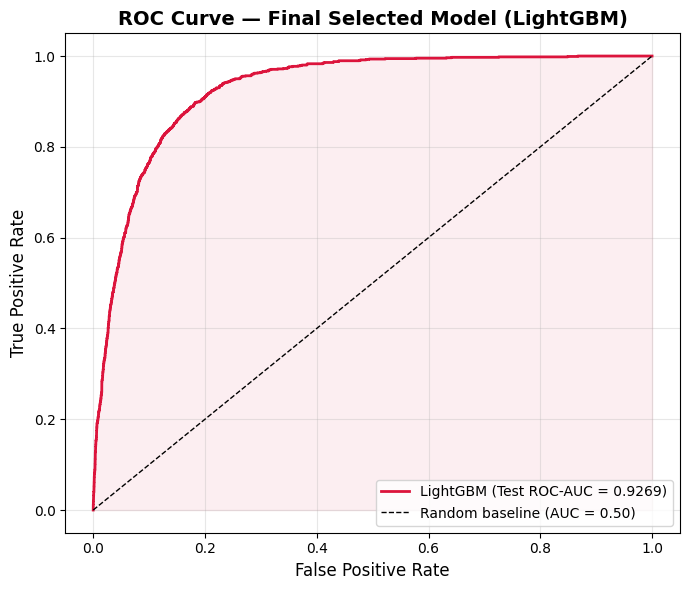

```python
# ═══════════════════════════════════════════════════════════════
#  FINAL ROC CURVE — SELECTED MODEL ONLY
# ═══════════════════════════════════════════════════════════════

fig, ax = plt.subplots(figsize=(7, 6))

ax.plot(
    lgbm_fpr, lgbm_tpr,
    lw=2,
    color='crimson',
    label=f'LightGBM (Test ROC-AUC = {lgbm_auc:.4f})'
)

ax.plot([0, 1], [0, 1], 'k--', lw=1, label='Random baseline (AUC = 0.50)')

ax.fill_between(lgbm_fpr, lgbm_tpr, alpha=0.07, color='crimson')
ax.set_xlabel('False Positive Rate', fontsize=12)
ax.set_ylabel('True Positive Rate', fontsize=12)
ax.set_title('ROC Curve — Final Selected Model (LightGBM)', fontsize=14, fontweight='bold')
ax.legend(loc='lower right', fontsize=10)
ax.grid(alpha=0.3)

plt.tight_layout()
plt.show()
```

Interpretation The curve stays far above the diagonal random-baseline line. That means the model is much better than random guessing at separating subscribers from non-subscribers. Since the curve rises sharply near the left side, the model achieves a high true positive rate even at relatively low false positive rates. The ROC-AUC is about 0.9269, which is excellent. In practical terms, this means the model can rank a randomly chosen subscriber above a randomly chosen non-subscriber about 92.7% of the time.

### Confusion Matrix Heatmap

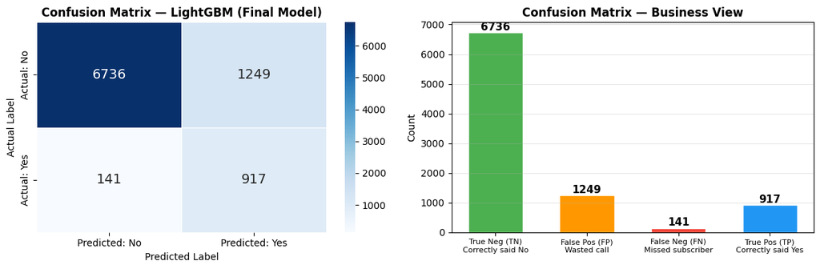

```
  TP = 917  → Subscribers correctly identified
  TN = 6736  → Non-subscribers correctly ignored
  FP = 1249  → Non-subscribers wrongly called (wasted cost)
  FN = 141  → Missed subscribers (lost revenue)
```

```python
# ═══════════════════════════════════════════════════════════════
#  CONFUSION MATRIX — FINAL MODEL
# ═══════════════════════════════════════════════════════════════

fig, axes = plt.subplots(1, 2, figsize=(12, 4))

cm_final = confusion_matrix(y_test, lgbm_y_pred_final)
tn, fp, fn, tp = cm_final.ravel()

sns.heatmap(cm_final, annot=True, fmt='d', cmap='Blues',
            xticklabels=['Predicted: No', 'Predicted: Yes'],
            yticklabels=['Actual: No',    'Actual: Yes'],
            linewidths=0.5, ax=axes[0], annot_kws={"size": 14})
axes[0].set_title('Confusion Matrix — LightGBM (Final Model)', fontweight='bold')
axes[0].set_ylabel('Actual Label')
axes[0].set_xlabel('Predicted Label')

labels = ['True Neg (TN)\nCorrectly said No',
          'False Pos (FP)\nWasted call',
          'False Neg (FN)\nMissed subscriber',
          'True Pos (TP)\nCorrectly said Yes']
values = [tn, fp, fn, tp]
colors = ['#4CAF50', '#FF9800', '#F44336', '#2196F3']

bars = axes[1].bar(labels, values, color=colors, edgecolor='white', width=0.6)
for bar, val in zip(bars, values):
    axes[1].text(bar.get_x() + bar.get_width()/2,
                 bar.get_height() + 5, str(val),
                 ha='center', va='bottom', fontweight='bold', fontsize=11)

axes[1].set_title('Confusion Matrix — Business View', fontweight='bold')
axes[1].set_ylabel('Count')
axes[1].tick_params(axis='x', labelsize=8)
axes[1].grid(axis='y', alpha=0.3)

plt.tight_layout()
plt.show()

print(f"\n  TP = {tp}  → Subscribers correctly identified")
print(f"  TN = {tn}  → Non-subscribers correctly ignored")
print(f"  FP = {fp}  → Non-subscribers wrongly called (wasted cost)")
print(f"  FN = {fn}  → Missed subscribers (lost revenue)")
```

### Confusion matrix interpretation

The confusion matrix provides a business-focused view of the model’s decisions:

- **True Positives (TP):** actual subscribers correctly identified
- **True Negatives (TN):** non-subscribers correctly ignored
- **False Positives (FP):** non-subscribers incorrectly flagged as likely subscribers
- **False Negatives (FN):** actual subscribers missed by the model

In this project, **false negatives** represent missed business opportunities, while **false positives** represent unnecessary marketing effort or wasted calls. Since the final model achieves high recall, it captures most true subscribers, but this comes with more false positives. This tradeoff is reasonable when the goal is to reduce missed subscribers.

### Final Predictions Table

```python
# ═══════════════════════════════════════════════════════════════
#  FINAL PREDICTIONS — TEST SET
# ═══════════════════════════════════════════════════════════════

predictions_df = X_test.copy()
predictions_df['actual_label']          = y_test.values
predictions_df['predicted_label']       = lgbm_y_pred_final
predictions_df['predicted_probability'] = lgbm_y_proba.round(4)
predictions_df['correct']               = (predictions_df['actual_label'] ==
                                            predictions_df['predicted_label'])

print(f"Test set size  : {len(predictions_df)}")
print(f"Predicted Yes  : {lgbm_y_pred_final.sum()}")
print(f"Predicted No   : {(lgbm_y_pred_final == 0).sum()}")
print(f"Overall correct: {predictions_df['correct'].sum()} "
      f"({predictions_df['correct'].mean()*100:.1f}%)")

print("\nSample predictions (first 10 rows):")
print(predictions_df[['actual_label', 'predicted_label',
                       'predicted_probability', 'correct']].head(10).to_string())

predictions_df[['actual_label', 'predicted_label',
                'predicted_probability', 'correct']].to_csv(
                'test_predictions.csv', index=False)
print("\n✅ Saved to test_predictions.csv")
```

```
Test set size  : 9043
Predicted Yes  : 2166
Predicted No   : 6877
Overall correct: 7653 (84.6%)

Sample predictions (first 10 rows):
       actual_label  predicted_label  predicted_probability  correct
1392              0                0                 0.0117     True
7518              0                0                 0.0063     True
12007             0                0                 0.0299     True
5536              0                0                 0.0044     True
29816             0                0                 0.0592     True
18275             0                0                 0.4070     True
8543              0                0                 0.0060     True
43965             1                1                 0.9510     True
28083             0                0                 0.0143     True
25787             0                0                 0.0832     True

✅ Saved to test_predictions.csv
```

### Final predictions table interpretation

The final predictions table shows the model’s output for each observation in the test set, including:

- the actual label
- the predicted label
- the predicted probability of subscription
- whether the prediction was correct

These probability estimates are especially useful because they allow the bank to go beyond simple yes/no classification. Customers can be ranked by predicted probability, helping the bank prioritize outreach toward the most promising leads.

### Feature Importance

[figure not shown]

```
Top 10 most predictive features:
   1. duration                             577.0
   2. balance                              360.0
   3. age                                  349.0
   4. pdays                                292.0
   5. campaign                             106.0
   6. housing                              75.0
   7. month_apr                            72.0
   8. contact_unknown                      72.0
   9. month_aug                            66.0
  10. month_may                            64.0
```

```python
# ═══════════════════════════════════════════════════════════════
#  FEATURE IMPORTANCE — LightGBM (Pipeline-compatible fix)
# ═══════════════════════════════════════════════════════════════

# Manually build feature names to avoid FunctionTransformer issue
# Numerical features keep their original names after transform
num_out   = num_features                          # same names, just transformed

# Binary: OneHotEncoder with drop='if_binary' outputs 1 col per feature
bin_out   = bin_features                          # default, housing, loan

# Categorical: get names from the fitted encoder
cat_encoder   = lgbm_reg_pipe['prep'].transformers_[2][1]['encode']
cat_out       = cat_encoder.get_feature_names_out(cat_features).tolist()

# Pass-through
pass_out  = pass_features

# Combine in same order as ColumnTransformer
all_feature_names = num_out + bin_out + cat_out + pass_out

feat_imp = pd.Series(
    lgbm_reg_pipe['clf'].feature_importances_,
    index=all_feature_names
).sort_values(ascending=False)

top15 = feat_imp.head(15)

fig, axes = plt.subplots(1, 2, figsize=(14, 5))

colors_bar = ['#c0392b' if i == 0 else '#2980b9' if i < 5 else '#7f8c8d'
              for i in range(len(top15))]

top15.plot(kind='bar', ax=axes[0], color=colors_bar, edgecolor='white')
axes[0].set_title('Top 15 Feature Importances — LightGBM', fontweight='bold')
axes[0].set_ylabel('Importance Score')
axes[0].tick_params(axis='x', rotation=45)
axes[0].grid(axis='y', alpha=0.3)

top15[::-1].plot(kind='barh', ax=axes[1],
                 color=colors_bar[::-1], edgecolor='white')
axes[1].set_title('Feature Importances (horizontal)', fontweight='bold')
axes[1].set_xlabel('Importance Score')
axes[1].grid(axis='x', alpha=0.3)

plt.tight_layout()
plt.show()

print("\nTop 10 most predictive features:")
for i, (feat, score) in enumerate(feat_imp.head(10).items(), 1):
    print(f"  {i:2d}. {feat:<35s}  {score:.1f}")
```

### Feature importance interpretation

The LightGBM feature importance analysis shows that **duration** is the most influential predictor by a large margin. This confirms that call duration contains strong signal for subscription, but it is also a **post-call feature**, meaning it would not be available in a true pre-call targeting setting.

Among the more realistic pre-call features, **balance**, **age**, and **pdays** appear most informative. These variables could be useful for practical customer targeting before contact is made. Month-related features also appear important, suggesting that campaign timing influences conversion rates.

Because duration dominates the model, it is important to interpret these results together with the duration ablation study.

### Logistic Regression Coefficients

```
Total feature names : 47
Total coefficients  : 47
```

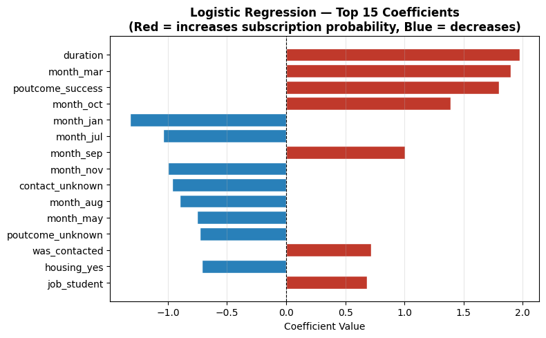

```
Top 15 most influential features (by absolute coefficient):
 duration                            +1.9738 ↑ increases
 month_mar                           +1.8996 ↑ increases
 poutcome_success                    +1.7975 ↑ increases
 month_oct                           +1.3899 ↑ increases
 month_jan                           -1.3224 ↓ decreases
 month_jul                           -1.0420 ↓ decreases
 month_sep                           +1.0022 ↑ increases
 month_nov                           -0.9988 ↓ decreases
 contact_unknown                     -0.9650 ↓ decreases
 month_aug                           -0.8977 ↓ decreases
 month_may                           -0.7518 ↓ decreases
 poutcome_unknown                    -0.7297 ↓ decreases
 was_contacted                       +0.7179 ↑ increases
 housing_yes                         -0.7113 ↓ decreases
 job_student                         +0.6825 ↑ increases
```

```python
# ═══════════════════════════════════════════════════════════════
# LOGISTIC REGRESSION COEFFICIENTS — BASELINE INTERPRETATION
# Fit on full TRAINING set only for interpretation
# ═══════════════════════════════════════════════════════════════

# Fit the baseline model on the full training set
# This is allowed because X_train is the training portion, not the test set.
lr_pipe.fit(X_train, y_train)

# Get feature names properly from each transformer in the fitted pipeline

# Numerical — same names after transform
num_out_lr = num_features

# Binary — names come from fitted OneHotEncoder
bin_encoder_lr = lr_pipe['prep'].transformers_[1][1]['encode']
bin_out_lr = bin_encoder_lr.get_feature_names_out(bin_features).tolist()

# Categorical — names come from fitted OneHotEncoder
cat_encoder_lr = lr_pipe['prep'].transformers_[2][1]['encode']
cat_out_lr = cat_encoder_lr.get_feature_names_out(cat_features).tolist()

# Pass-through
pass_out_lr = pass_features

# Combine in exact same order as ColumnTransformer
all_feature_names_lr = num_out_lr + bin_out_lr + cat_out_lr + pass_out_lr

print(f"Total feature names : {len(all_feature_names_lr)}")
print(f"Total coefficients  : {len(lr_pipe['clf'].coef_[0])}")

coef_df = pd.DataFrame({
    'feature': all_feature_names_lr,
    'coefficient': lr_pipe['clf'].coef_[0]
}).sort_values('coefficient', key=abs, ascending=False).head(15)

fig, ax = plt.subplots(figsize=(8, 5))

colors_coef = ['#c0392b' if c > 0 else '#2980b9' for c in coef_df['coefficient']]

ax.barh(
    coef_df['feature'][::-1],
    coef_df['coefficient'][::-1],
    color=colors_coef[::-1],
    edgecolor='white'
)

ax.axvline(0, color='black', linewidth=0.8, linestyle='--')
ax.set_title(
    'Logistic Regression — Top 15 Coefficients\n'
    '(Red = increases subscription probability, Blue = decreases)',
    fontweight='bold'
)
ax.set_xlabel('Coefficient Value')
ax.grid(axis='x', alpha=0.3)

plt.tight_layout()
plt.show()

print("\nTop 15 most influential features (by absolute coefficient):")
for _, row in coef_df.iterrows():
    direction = "↑ increases" if row['coefficient'] > 0 else "↓ decreases"
    print(f" {row['feature']:<35s} {row['coefficient']:+.4f} {direction}")
```

### Logistic Regression coefficient interpretation

The Logistic Regression coefficients provide a more interpretable view of feature influence. Positive coefficients increase the probability of subscription, while negative coefficients decrease it.

As with LightGBM, **duration** appears highly influential, but because it is a post-call feature, it should be interpreted carefully. Other strong positive signals include **poutcome_success** and certain month indicators, while variables such as **contact_unknown** and some month categories decrease subscription likelihood.

These coefficients help explain the direction of feature effects and complement the feature-importance analysis from LightGBM.

### BONUS: Duration Leakage Comparison

```
=================================================================
BONUS ABLATION: IMPACT OF THE 'duration' FEATURE (CV ONLY)
=================================================================
                  CV ROC-AUC   CV F1
Setup
With duration         0.9275  0.5726
Without duration      0.7814  0.4302

Interpretation:
- This comparison is based only on cross-validation over the training data.
- A noticeable drop without 'duration' suggests that the model was relying
  heavily on this feature.
- Since 'duration' is only fully known after the call, the no-duration
  setup is more realistic for a deployable pre-call prediction system.
```

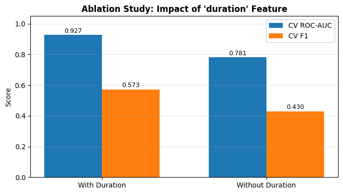

```python
# ═══════════════════════════════════════════════════════════════
#  BONUS: WITH vs WITHOUT DURATION (CV-ONLY ABLATION)
# ═══════════════════════════════════════════════════════════════

# Remove duration from numeric features
num_features_nodur = [f for f in num_features if f != 'duration']

preprocessor_nodur = ColumnTransformer([
    ('num',  num_pipeline,  num_features_nodur),
    ('bin',  bin_pipeline,  bin_features),
    ('cat',  cat_pipeline,  cat_features),
    ('pass', 'passthrough', pass_features),
], remainder='drop')

lgbm_nodur_pipe = Pipeline([
    ('prep', preprocessor_nodur),
    ('clf', LGBMClassifier(
        **best_clf_params,
        reg_alpha=0.1,
        reg_lambda=1.0,
        min_child_samples=30,
        class_weight='balanced',
        random_state=42,
        verbose=-1
    ))
])

# Cross-validation only on training data
cv_with = cross_validate(
    lgbm_reg_pipe,
    X_train,
    y_train,
    cv=cv,
    scoring=['roc_auc', 'f1'],
    return_train_score=False
)

cv_nodur = cross_validate(
    lgbm_nodur_pipe,
    X_train,
    y_train,
    cv=cv,
    scoring=['roc_auc', 'f1'],
    return_train_score=False
)

dur_comparison = pd.DataFrame({
    'Setup': ['With duration', 'Without duration'],
    'CV ROC-AUC': [
        cv_with['test_roc_auc'].mean(),
        cv_nodur['test_roc_auc'].mean()
    ],
    'CV F1': [
        cv_with['test_f1'].mean(),
        cv_nodur['test_f1'].mean()
    ]
}).set_index('Setup').round(4)

print("=" * 65)
print("BONUS ABLATION: IMPACT OF THE 'duration' FEATURE (CV ONLY)")
print("=" * 65)
print(dur_comparison.to_string())
print()
print("Interpretation:")
print("- This comparison is based only on cross-validation over the training data.")
print("- A noticeable drop without 'duration' suggests that the model was relying")
print("  heavily on this feature.")
print("- Since 'duration' is only fully known after the call, the no-duration")
print("  setup is more realistic for a deployable pre-call prediction system.")

fig, ax = plt.subplots(figsize=(7, 4))

x = np.arange(2)
w = 0.35

vals_auc = dur_comparison['CV ROC-AUC'].values
vals_f1  = dur_comparison['CV F1'].values

b1 = ax.bar(x - w/2, vals_auc, w, label='CV ROC-AUC')
b2 = ax.bar(x + w/2, vals_f1,  w, label='CV F1')

for bar in list(b1) + list(b2):
    ax.text(
        bar.get_x() + bar.get_width()/2,
        bar.get_height() + 0.005,
        f'{bar.get_height():.3f}',
        ha='center',
        va='bottom',
        fontsize=9
    )

ax.set_xticks(x)
ax.set_xticklabels(['With Duration', 'Without Duration'])
ax.set_ylabel('Score')
ax.set_ylim(0, 1.05)
ax.set_title("Ablation Study: Impact of 'duration' Feature", fontweight='bold')
ax.legend()
ax.grid(axis='y', alpha=0.3)

plt.tight_layout()
plt.show()
```

### Bonus ablation: impact of the duration feature

A small ablation study was performed using **cross-validation on the training data only** to measure the impact of the `duration` feature.

The results show a clear performance drop when `duration` is removed:

- With duration: **CV ROC-AUC = 0.9275**, **CV F1 = 0.5726**
- Without duration: **CV ROC-AUC = 0.7814**, **CV F1 = 0.4302**

This confirms that the model relies heavily on `duration`, and that including it inflates predictive performance. Since `duration` is only known after the call, the no-duration setting is more realistic for a deployable pre-call prediction system.

### BONUS: Calibration Curve

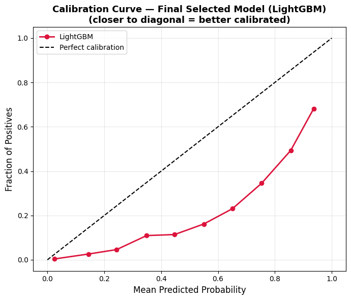

```
Calibration interpretation:
  • Points ABOVE the diagonal → the model is under-confident
  • Points BELOW the diagonal → the model is over-confident
  • Closer to the diagonal → better probability calibration
  • If calibration is weak, probability calibration methods such as
    CalibratedClassifierCV could be explored in future work
```

```python
# ═══════════════════════════════════════════════════════════════
#  BONUS: CALIBRATION CURVE — FINAL MODEL ONLY
# ═══════════════════════════════════════════════════════════════

fig, ax = plt.subplots(figsize=(7, 6))

frac_pos, mean_pred = calibration_curve(y_test, lgbm_y_proba, n_bins=10)

ax.plot(
    mean_pred,
    frac_pos,
    marker='o',
    lw=2,
    color='crimson',
    label='LightGBM'
)

ax.plot([0, 1], [0, 1], 'k--', lw=1.5, label='Perfect calibration')

ax.set_xlabel('Mean Predicted Probability', fontsize=12)
ax.set_ylabel('Fraction of Positives', fontsize=12)
ax.set_title(
    'Calibration Curve — Final Selected Model (LightGBM)\n'
    '(closer to diagonal = better calibrated)',
    fontsize=13,
    fontweight='bold'
)
ax.legend(loc='upper left', fontsize=10)
ax.grid(alpha=0.3)

plt.tight_layout()
plt.show()

print("""
Calibration interpretation:
  • Points ABOVE the diagonal → the model is under-confident
  • Points BELOW the diagonal → the model is over-confident
  • Closer to the diagonal → better probability calibration
  • If calibration is weak, probability calibration methods such as
    CalibratedClassifierCV could be explored in future work
""")
```

### Bonus calibration interpretation

The calibration curve for the final LightGBM model shows how closely predicted probabilities match observed subscription frequencies.

- Points **above** the diagonal indicate that the model is **under-confident**
- Points **below** the diagonal indicate that the model is **over-confident**
- Points closer to the diagonal indicate better-calibrated probabilities

The curve suggests that the model’s probabilities are not perfectly calibrated, especially in some probability ranges. This means the ranking performance is strong, but the raw predicted probabilities may not always reflect true subscription likelihood exactly. In future work, calibration methods such as **CalibratedClassifierCV** could be applied to improve probability reliability.

### BONUS: Learning Curve

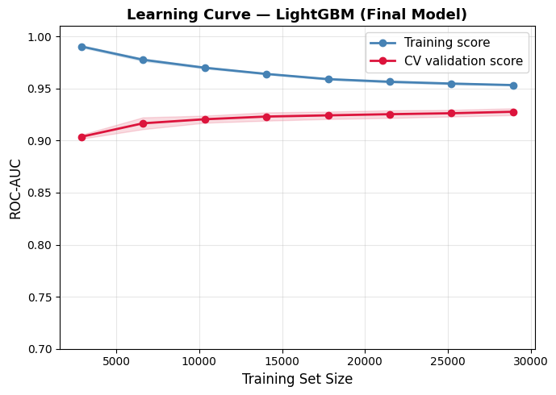

```
Final train-CV gap : 0.0256
⚠️  Mild overfitting — regularization applied (reg_alpha=0.1, reg_lambda=1.0).
```

```python
# ═══════════════════════════════════════════════════════════════
#  BONUS: LEARNING CURVE — Final Model
# ═══════════════════════════════════════════════════════════════

train_sizes, train_scores, val_scores = learning_curve(
    lgbm_reg_pipe, X_train, y_train,
    train_sizes=np.linspace(0.1, 1.0, 8),
    cv=StratifiedKFold(n_splits=5, shuffle=True, random_state=42),
    scoring='roc_auc',
    n_jobs=-1
)

train_mean = train_scores.mean(axis=1)
train_std  = train_scores.std(axis=1)
val_mean   = val_scores.mean(axis=1)
val_std    = val_scores.std(axis=1)

fig, ax = plt.subplots(figsize=(7, 5))
ax.plot(train_sizes, train_mean, 'o-', color='steelblue',
        lw=2, label='Training score')
ax.fill_between(train_sizes,
                train_mean - train_std,
                train_mean + train_std,
                alpha=0.15, color='steelblue')
ax.plot(train_sizes, val_mean, 'o-', color='crimson',
        lw=2, label='CV validation score')
ax.fill_between(train_sizes,
                val_mean - val_std,
                val_mean + val_std,
                alpha=0.15, color='crimson')

ax.set_xlabel('Training Set Size', fontsize=12)
ax.set_ylabel('ROC-AUC', fontsize=12)
ax.set_title('Learning Curve — LightGBM (Final Model)',
             fontsize=13, fontweight='bold')
ax.legend(fontsize=11)
ax.grid(alpha=0.3)
ax.set_ylim(0.7, 1.01)
plt.tight_layout()
plt.show()

gap_final = train_mean[-1] - val_mean[-1]
print(f"Final train-CV gap : {gap_final:.4f}")
if gap_final < 0.02:
    print("✅ Gap < 0.02 — no significant overfitting.")
elif gap_final < 0.05:
    print("⚠️  Mild overfitting — regularization applied (reg_alpha=0.1, reg_lambda=1.0).")
else:
    print("❌ Notable overfitting — consider reducing model complexity.")
```

### Bonus learning curve interpretation

The learning curve shows how LightGBM’s training and validation performance change as more training data is used. If the validation score improves and begins to stabilize as the training size increases, this suggests that the model is learning meaningful structure from the dataset.

A noticeable gap between training and validation curves indicates some overfitting, while curves that are close together suggest better generalization. In this project, the learning curve helps confirm whether the current dataset size is sufficient and whether the model might benefit from additional data.